# Lab 2

Jeffrey Kinard

9/13/2020

## Searching for the Best Chocolates

**1. How are the ratings distributed? Create both a histogram and a boxplot and describe them. Don’t forget to mention outliers, if there are any.**

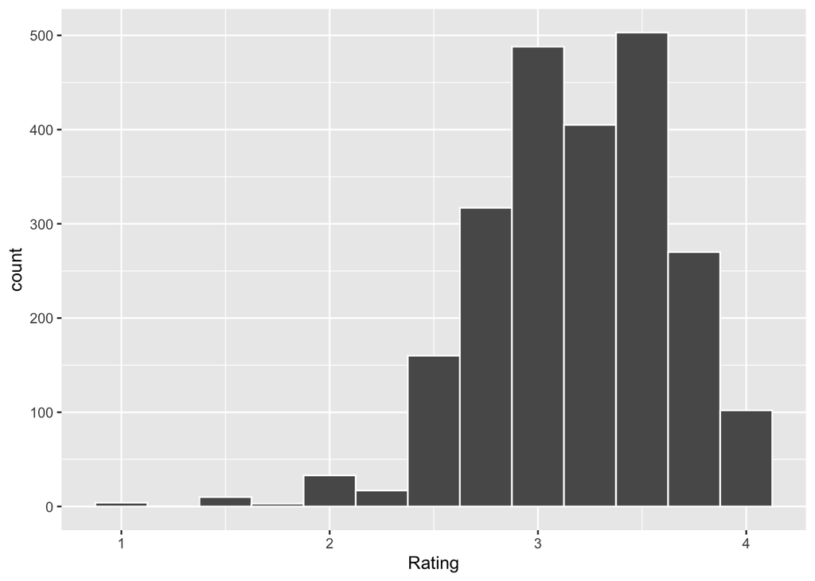

```r
choco <- read.csv("https://raw.githubusercontent.com/xdaiISU/ds202materials/master/hwlabs/data/choco.csv")

ggplot(choco, aes(x=Rating)) + geom_histogram(bins=13, color="white")
```

As can be seen by the bar plot above, the ratings are very clearly skewed left. The ratings tend to be at or above 2.5 and below 4.0.

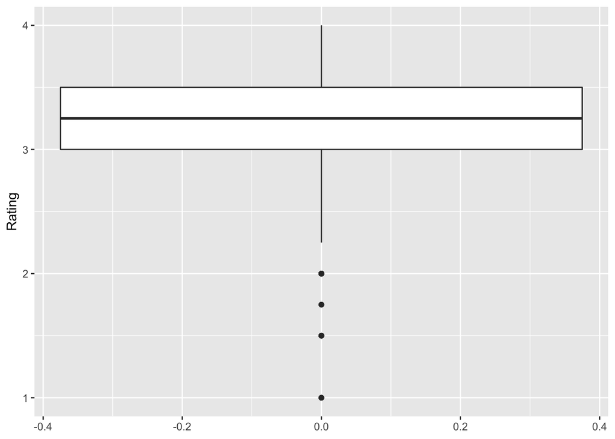

```r
ggplot(choco, aes(y=Rating)) + geom_boxplot()
```

The boxplot above shows the median rating is about 3.25 with the 25 percentile and 75th percentile being at 3.0 and 3.5, respectively. There are some outliers shown in the plot. There are repeated outlier values, but they are all either, 2.0, 1.75, 1.5 or 1.0 rating. This further proves that almost all of the ratings appear to be above 2.5.

**2. How does the number of ratings depend on the year? Draw a bar chart of the number of reports.**

```r
d <- choco[, c("Date", "Rating")]
kable(cor(d))
```

|  | Date | Rating |
| --- | --- | --- |
| Date | 1.0000000 | 0.0859668 |
| Rating | 0.0859668 | 1.0000000 |

```r
d <- table(choco[, c("Date")])
kable(d)
```

| Var1 | Freq |
| --- | --- |
| 2006 | 62 |
| 2007 | 73 |
| 2008 | 92 |
| 2009 | 123 |
| 2010 | 110 |
| 2011 | 163 |
| 2012 | 194 |
| 2013 | 184 |
| 2014 | 247 |
| 2015 | 284 |
| 2016 | 219 |
| 2017 | 105 |
| 2018 | 228 |
| 2019 | 195 |
| 2020 | 33 |

The table above shows the number of ratings per year. It is clear from the numbers that the numbers tend to peak around 2014-2016 range, but let’s visualize the data to confirm.

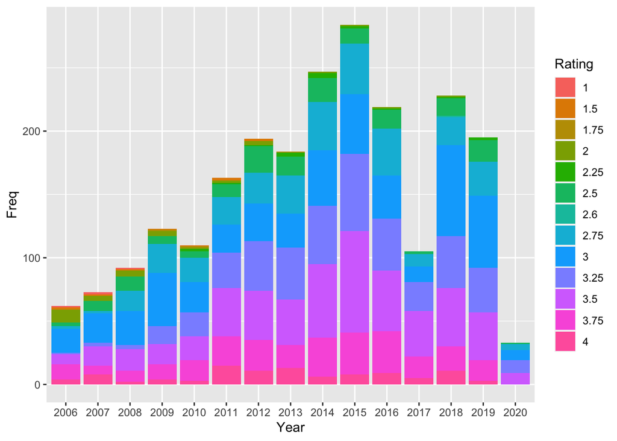

```r
d <- data.frame(table(choco$Date, choco$Rating))
x <- c("Year", "Rating", "Freq")
colnames(d) <- x
ggplot(d, aes(fill=Rating, x=Year, y=Freq)) + geom_bar(stat="identity")
```

To simplify the data into the specific question - *How does the number of ratings depend on the year?* - let us also plot the data using a simple count of the number of reviews, and disregard the breakdown of ratings per year.

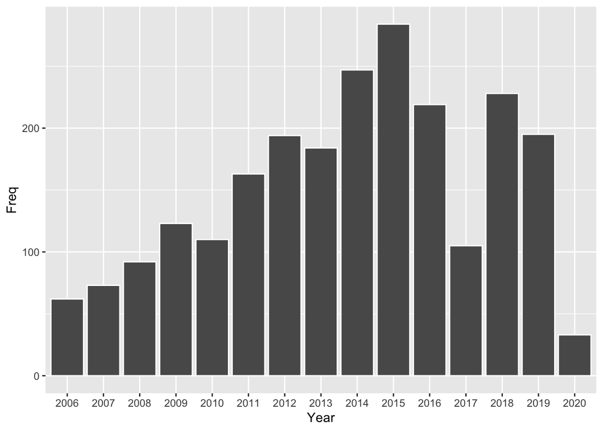

```r
d <- data.frame(table(choco[, c("Date")]))
x <- c("Year", "Freq")
colnames(d) <- x
ggplot(d, aes(x=Year, y=Freq)) + geom_bar(stat="identity", color="white")
```

**3. Do ratings depend on the cacao percentage of a chocolate bar? Create both numerical and graphical summaries, and explain.**

```r
d_to_correlate <- choco[, c("Rating", "Cocoa_Percent")]
cor(d_to_correlate)
```

```
##                   Rating Cocoa_Percent
## Rating         1.0000000    -0.1510178
## Cocoa_Percent -0.1510178     1.0000000
```

As used in the previous question, a correlation matrix has been used here to determine the correlation between the percentage of cocoa and the rating the chocolate received. There does not appear to be a strong correlation, but there is a slight inverse relationship between the cocoa percentage and the rating as the score is -0.15. However, let us make some plots to make sure this trend is visually apparent.

```r
cocoaPercentVector <- choco[, c("Cocoa_Percent")]
vectorOfFives <- seq(from = 0, to = 100, by = 5)
cuts <- c(-Inf, vectorOfFives[-1]-diff(vectorOfFives)/2, Inf)
newPercents <- vectorOfFives[findInterval(cocoaPercentVector, cuts)]
```

*For this problem, the percentages have all been rounded to the nearest 5% as that allows us to read the data easier. Otherwise, there could be 100 different possible values.*

```r
kable(table(choco$Rating, newPercents))
```

|  | 40 | 45 | 50 | 55 | 60 | 65 | 70 | 75 | 80 | 85 | 90 | 100 |
| --- | --- | --- | --- | --- | --- | --- | --- | --- | --- | --- | --- | --- |
| 1 | 0 | 0 | 0 | 0 | 0 | 0 | 2 | 1 | 0 | 0 | 0 | 1 |
| 1.5 | 0 | 0 | 0 | 0 | 0 | 2 | 2 | 0 | 0 | 1 | 1 | 4 |
| 1.75 | 0 | 0 | 0 | 0 | 0 | 0 | 1 | 0 | 0 | 0 | 0 | 2 |
| 2 | 0 | 0 | 0 | 1 | 3 | 1 | 7 | 11 | 3 | 1 | 2 | 4 |
| 2.25 | 0 | 0 | 0 | 1 | 0 | 1 | 8 | 4 | 1 | 1 | 0 | 1 |
| 2.5 | 0 | 0 | 0 | 3 | 11 | 11 | 74 | 41 | 10 | 6 | 2 | 1 |
| 2.6 | 0 | 0 | 0 | 0 | 0 | 0 | 1 | 0 | 0 | 0 | 0 | 0 |
| 2.75 | 1 | 1 | 0 | 7 | 10 | 21 | 156 | 77 | 27 | 11 | 3 | 3 |
| 3 | 0 | 0 | 0 | 2 | 23 | 37 | 275 | 107 | 25 | 10 | 5 | 4 |
| 3.25 | 0 | 0 | 0 | 4 | 17 | 31 | 234 | 83 | 24 | 6 | 5 | 1 |
| 3.5 | 0 | 0 | 0 | 2 | 9 | 52 | 311 | 88 | 25 | 14 | 1 | 1 |
| 3.75 | 0 | 0 | 1 | 0 | 2 | 29 | 171 | 53 | 13 | 0 | 1 | 0 |
| 4 | 0 | 0 | 0 | 0 | 1 | 9 | 70 | 20 | 1 | 0 | 1 | 0 |

The table above shows a fairly visually appealing breakdown of the number of each possible review score based on the cocoa percentage. It can be seen that there is a large number of high reviews (above a 3.0) in the 65% - 80% cocoa range.

This table very clearly shows a large number of high reviews in this 65% - 80% range, but to make sure this is the case on a plot, let’s plot the data.

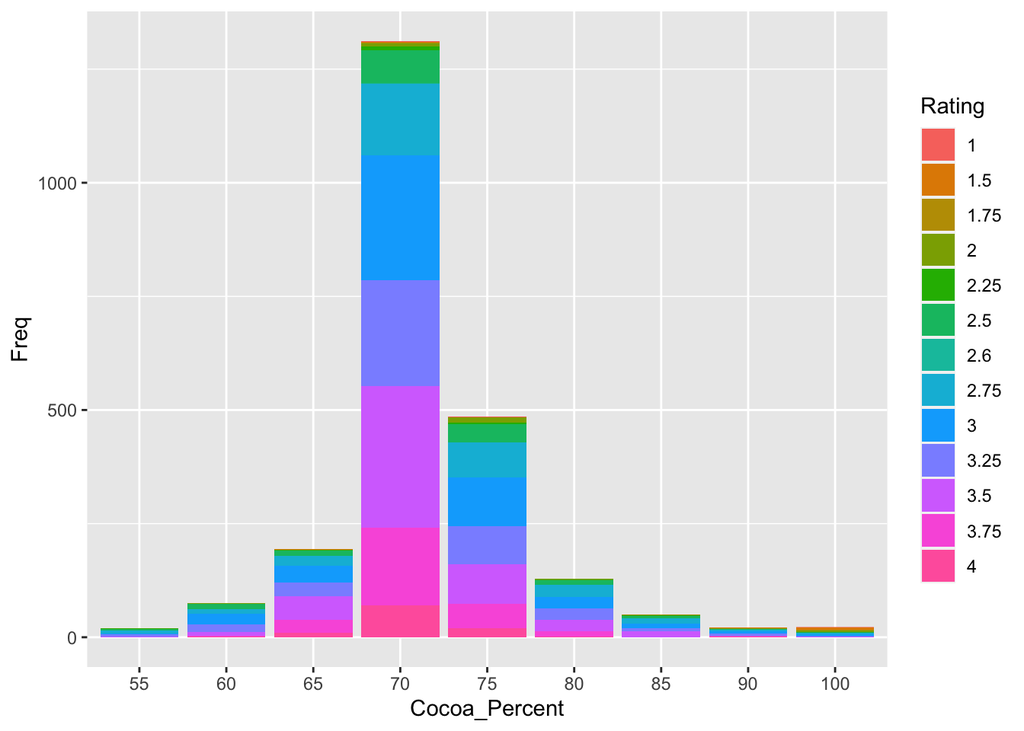

```r
chocoCopy <- choco
chocoCopy$Cocoa_Percent <- newPercents
chocoNoOutliers <- chocoCopy[chocoCopy$Cocoa_Percent >= 55,]
df <- data.frame(table(chocoNoOutliers$Cocoa_Percent, chocoNoOutliers$Rating))
x <- c("Cocoa_Percent", "Rating", "Freq")
colnames(df) <- x
ggplot(df, aes(fill=Rating, x=Cocoa_Percent, y=Freq)) + geom_bar(stat="identity")
```

This plot proves that chocolate tends to have more high reviews in the mid range of its possible cocoa percentages. However, this is a pure total number of reviews. This does not account for the average score in each range. A taller bar in this plot just means there were more data points with that percentage, not that the data points were actually better on average.

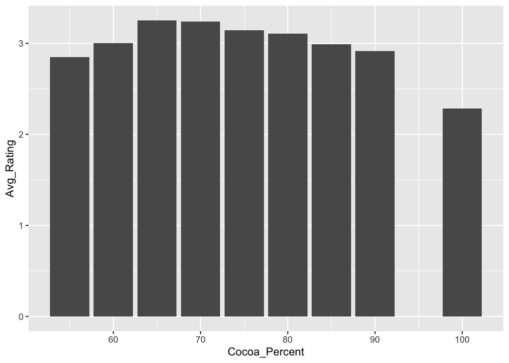

```r
chocoNoOutliers <- chocoCopy[chocoCopy$Cocoa_Percent >= 55, c("Cocoa_Percent", "Rating")]
aggregatedTable <- aggregate(x=chocoNoOutliers$Rating,by=list(chocoNoOutliers$Cocoa_Percent), FUN=mean)
x <- c("Cocoa_Percent", "Avg_Rating")
colnames(aggregatedTable) <- x
ggplot(aggregatedTable, aes(x=Cocoa_Percent, y=Avg_Rating)) + geom_bar(stat="identity")
```

This final plot shows the average score based on the cocoa percentage. Luckily, it appears that the trends found in the previous plot hold true here. The average rating is clearly higher in the mid-range of possible cocoa percentages. This means there is a fairly symmetric distribution of average rating based on cocoa percentage. This also explains the slight correlation found above. There is a stronger negative correlation than there is positive correlation, but since both types exist (due to a symmetric distribution) the negative values shows up in a negligible amount.

**4. How do different characteristics of the chocolate compare? To elaborate, which characteristics tend to be more favorable and which ones are not? Create both numerical and graphical summaries, and explain.**

```r
characteristics <- c(as.character(choco$Characteristics1),
                     as.character(choco$Characteristics2),
                     as.character(choco$Characteristics3),
                     as.character(choco$Characteristics4))
characteristics <- characteristics[!is.na(characteristics)]
r <- data.frame(table(characteristics))
r <- r[r$Freq > 20,]
uniqueCharacteristics <- unique(r$characteristics)
uniqueCharacteristics
```

```
##  [1] acidic       astringent   banana       basic cocoa  bitter
##  [6] black pepper brownie      burnt        caramel      cherry
## [11] citrus       coarse       cocoa        coffee       complex
## [16] creamy       dairy        dirty        dried fruit  dry
## [21] earthy       fatty        floral       fruit        fruity
## [26] grassy       gritty       hammy        honey        intense
## [31] marshmallow  melon        metallic     mild bitter  mild fruit
## [36] molasses     nut          nuts         nutty        off
## [41] off notes    oily         pungent      red berry    rich
## [46] rich cocoa   roasty       rubber       rubbery      sandy
## [51] smoke        smokey       smooth       sour         spice
## [56] spicy        sticky       strawberry   sweet        tart
## [61] tobacco      vanilla      vegetal      woody
## 850 Levels:  "Andes" mint accesible accessible acidic ... yogurt
```

The above list shows every unique characteristic found on at least 20 samples in the dataset. From this, we can do some data analysis to determine which one crrelates with a highly-rated chocolate sample.

```r
compare <- choco[, c("Characteristics1", "Characteristics2", "Characteristics3",
                     "Characteristics4", "Rating")]
d <- data.frame(Characteristic=character(0), mean=numeric(0), median=numeric(0), stringsAsFactors=FALSE)
for (element in uniqueCharacteristics) {
  b <- compare[compare$Characteristics1 == element |
               compare$Characteristics2 == element |
               compare$Characteristics3 == element |
               compare$Characteristics4 == element, c("Rating")]
  d[nrow(d) + 1,] = c(element, mean(b, na.rm=TRUE), median(b, na.rm=TRUE))
}
d$mean <- as.numeric(as.character(d$mean))
d$median <- as.numeric(as.character(d$median))
d[,-1] <- round(d[,-1],2)
```

```r
top10means <- tail(d[with(d, order(mean)),], 10)
kable(top10means)
```

|  | Characteristic | mean | median |
| --- | --- | --- | --- |
| 38 | nuts | 3.40 | 3.5 |
| 32 | melon | 3.41 | 3.5 |
| 19 | dried fruit | 3.42 | 3.5 |
| 46 | rich cocoa | 3.43 | 3.5 |
| 58 | strawberry | 3.45 | 3.5 |
| 53 | smooth | 3.46 | 3.5 |
| 45 | rich | 3.47 | 3.5 |
| 16 | creamy | 3.48 | 3.5 |
| 10 | cherry | 3.50 | 3.5 |
| 15 | complex | 3.55 | 3.5 |

This table shows the ten characteristics with the highest ratings, on average. This shows that a chocolate sample with a ‘complex’ characteristic has the highest rating on average.

Below, it can be seen graphically how the top 10 characteristics compare in terms of ratings.

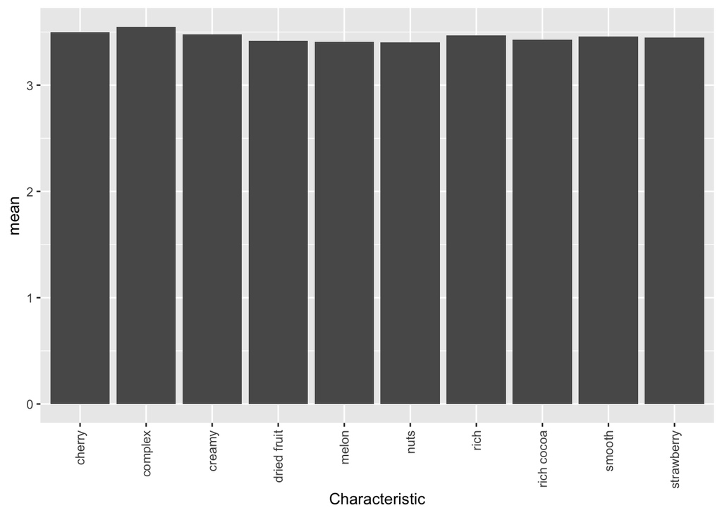

```r
ggplot(top10means, aes(x=Characteristic, y=mean)) + geom_bar(stat="identity") + theme(axis.text.x = element_text(angle = 90, vjust = 0.5, hjust=1))
```

```r
#m <- tail(d[with(d, order(median)),], 39)
#medians <- tail(m[with(m, order(mean)),], 10)
#kable(medians)
bottom10means <- head(d[with(d, order(mean)),], 10)
kable(bottom10means)
```

|  | Characteristic | mean | median |
| --- | --- | --- | --- |
| 41 | off notes | 2.58 | 2.50 |
| 8 | burnt | 2.70 | 2.75 |
| 48 | rubber | 2.71 | 2.75 |
| 5 | bitter | 2.72 | 2.75 |
| 40 | off | 2.74 | 2.75 |
| 43 | pungent | 2.74 | 2.75 |
| 33 | metallic | 2.76 | 2.75 |
| 49 | rubbery | 2.84 | 2.75 |
| 62 | vanilla | 2.85 | 2.75 |
| 18 | dirty | 2.86 | 2.75 |

This table shows the ten characteristics with the lowest ratings, on average. THis shows that a chocolate sample with an ‘off notes’ characteristic has the lowest rating, on average.

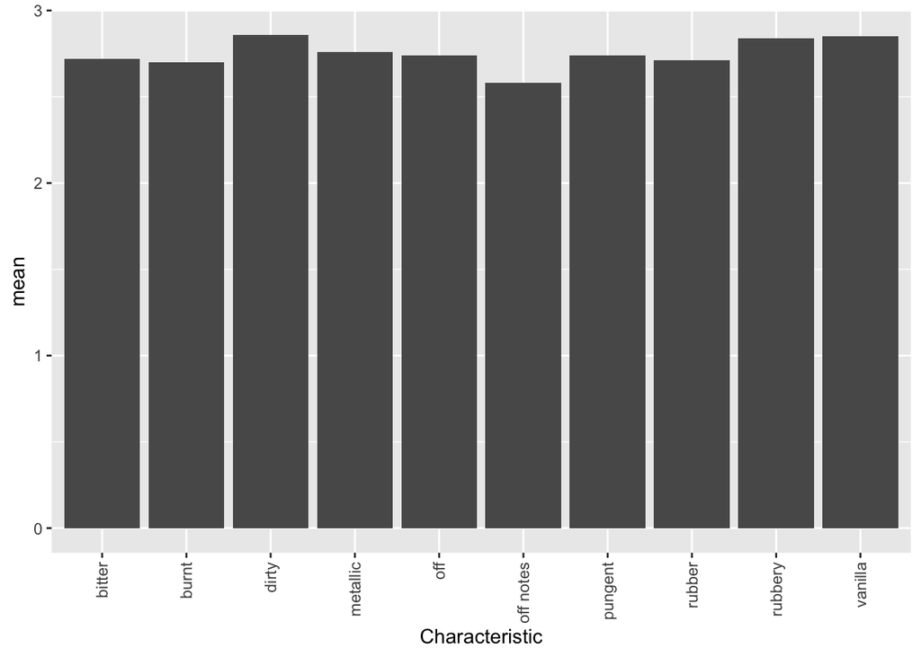

```r
ggplot(bottom10means, aes(x=Characteristic, y=mean)) + geom_bar(stat="identity") + theme(axis.text.x = element_text(angle = 90, vjust = 0.5, hjust=1))
```

Finally, let’s look below at a graphical comparison of all of the characteristics that have at least 20 samples in the dataset:

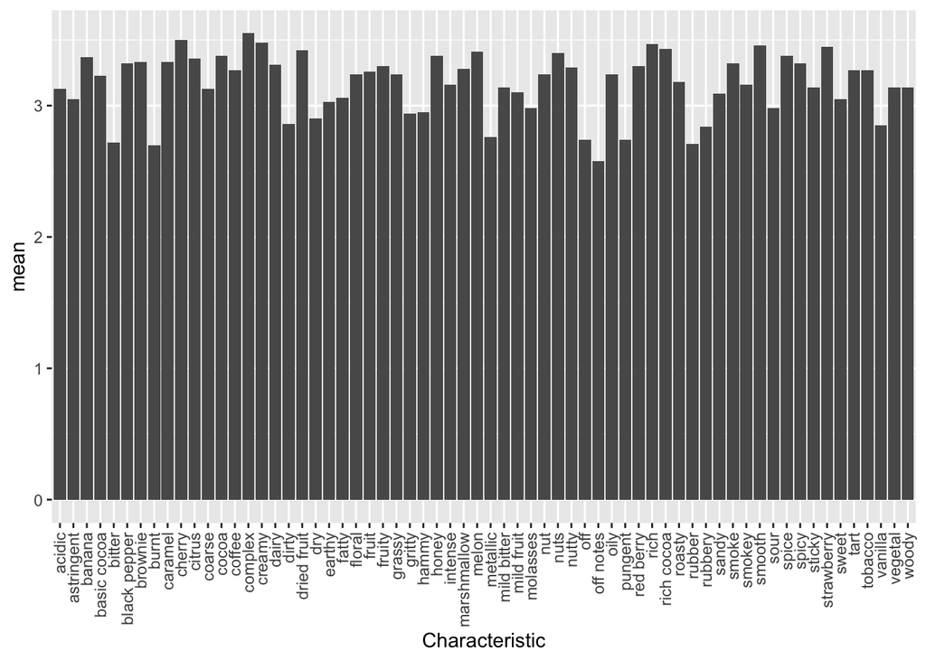

```r
total <- rbind(bottom10means, top10means)
ggplot(d, aes(x=Characteristic, y=mean)) + geom_bar(stat="identity") + theme(axis.text.x = element_text(angle = 90, vjust = 0.5, hjust=1))
```

**5. Brainstorm two analyses you would like to perform with your teammate. Describe in plain language what comparisons are you making. Create suitable numerical and graphical summaries for your analyses. Describe the results.**

For the two analyses, I will compare rating patterns between the USA and France, and I will determine ratings trends throughout the years.

For the first analysis, I will look at the distribution of results for the U.S.A. v. France.

```r
usaFrance <- choco[choco$Location == "U.S.A." | choco$Location == "France", c("Location", "Rating")]
summary(usaFrance)
```

```
##       Location       Rating
##  U.S.A.   :966   Min.   :1.500
##  France   :175   1st Qu.:3.000
##  Amsterdam:  0   Median :3.250
##  Argentina:  0   Mean   :3.183
##  Australia:  0   3rd Qu.:3.500
##  Austria  :  0   Max.   :4.000
##  (Other)  :  0
```

THe above summary shows that the U.S.A. has over 5.5 times the amount of entries as France. This means that when looking at the data, this will need to be taken into account before making the final analysis. The joint distribution between the two countries in terms of ratings is also shown.

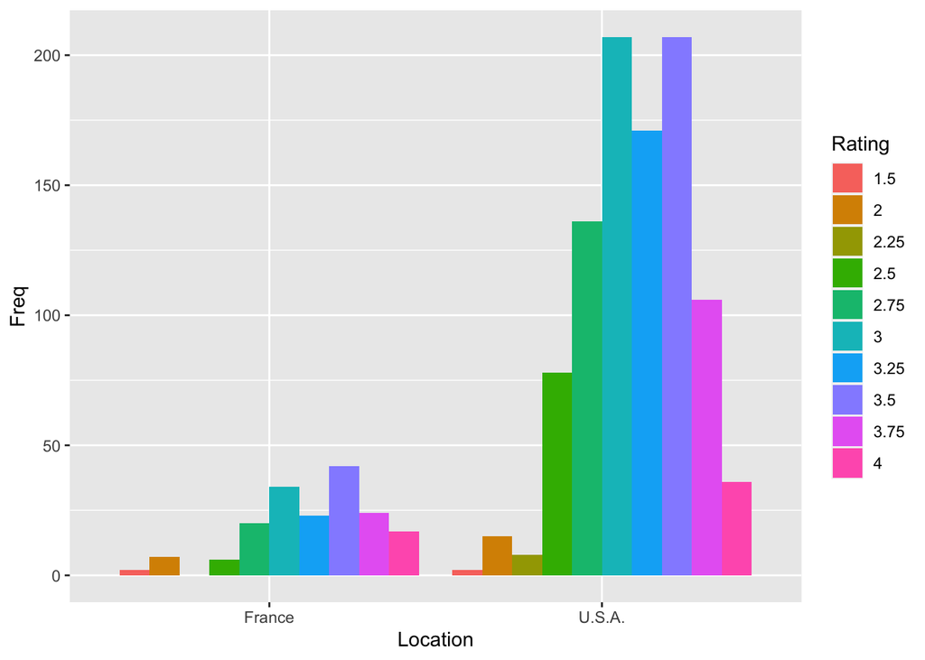

```r
usaFranceDf <- data.frame(table(usaFrance$Location, usaFrance$Rating))
usaFranceDf <- usaFranceDf[usaFranceDf$Var1 == "U.S.A." | usaFranceDf$Var1 == "France",]
x <- c("Location", "Rating", "Freq")
colnames(usaFranceDf) <- x
ggplot(usaFranceDf, aes(fill=Rating, x=Location, y=Freq)) + geom_bar(stat="identity", position="dodge")
```

The above plot shows the breakdown of results for the two countries. It can be clearly seen that France ratings skew left. This means that France tends to have higher ratings than it does lower ratings. Looking at the U.S.A. side, it can be seen that the distribution is slightly more symmetrical and uniform. Therefore, the U.S.A tends to be slightly more in the middle in terms of overall rating. However, the graphs are both very similar and therefore should result in similar average ratings. This can be verified in the below summaries:

```r
usa <- choco[choco$Location == "U.S.A.", c("Location", "Rating")]
france <- choco[choco$Location == "France", c("Location", "Rating")]
summary(usa)
```

```
##       Location       Rating
##  U.S.A.   :966   Min.   :1.500
##  Amsterdam:  0   1st Qu.:3.000
##  Argentina:  0   Median :3.250
##  Australia:  0   Mean   :3.171
##  Austria  :  0   3rd Qu.:3.500
##  Belgium  :  0   Max.   :4.000
##  (Other)  :  0
```

```r
summary(france)
```

```
##       Location       Rating
##  France   :175   Min.   :1.50
##  Amsterdam:  0   1st Qu.:3.00
##  Argentina:  0   Median :3.25
##  Australia:  0   Mean   :3.25
##  Austria  :  0   3rd Qu.:3.50
##  Belgium  :  0   Max.   :4.00
##  (Other)  :  0
```

The above summaries prove that the averages are similar. In fact, France only has a 0.079 higher average rating than the U.S.A. Of course, the fact that France has far fewer entries should be considered as well.

For the second analysis, I will now look at how the rating trends have changed over time.

```r
years <- choco[, c("Date", "Rating")]
aggregatedTable <- aggregate(x=years$Rating,by=list(years$Date), FUN=mean)
x <- c("Year", "Avg_Rating")
colnames(aggregatedTable) <- x
kable(aggregatedTable)
```

| Year | Avg_Rating |
| --- | --- |
| 2006 | 3.004032 |
| 2007 | 3.102740 |
| 2008 | 3.000000 |
| 2009 | 3.073171 |
| 2010 | 3.152273 |
| 2011 | 3.257669 |
| 2012 | 3.180412 |
| 2013 | 3.197011 |
| 2014 | 3.189271 |
| 2015 | 3.244718 |
| 2016 | 3.226027 |
| 2017 | 3.361905 |
| 2018 | 3.192325 |
| 2019 | 3.133333 |
| 2020 | 3.159091 |

The above table shows the breakdown of the average rating over time. This can be better visualized below:

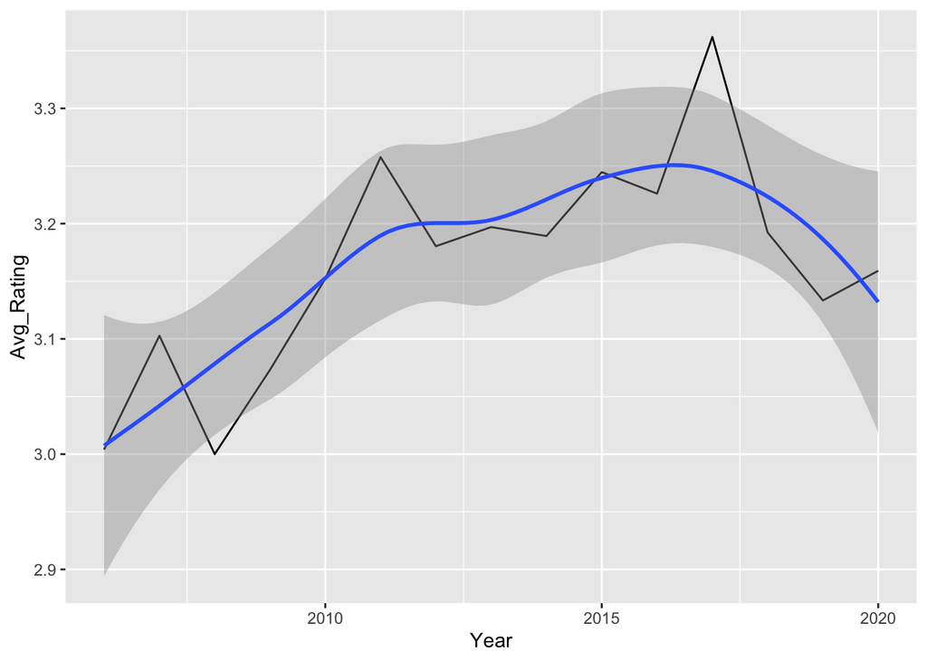

```r
ggplot(aggregatedTable, aes(x=Year, y=Avg_Rating)) + geom_line(stat="identity") + geom_smooth(method="loess", se=TRUE, fullrange=FALSE, level=0.95)
```

There is a clear rising trend in average rating until 2017 where the average rating begins to take a sharp decline in average rating. A regression line has been added to emphasize this point.